# Decision_Tree_Live_Implementation

## **Decision Tree Implementation**

Doc: https://scikit-learn.org/stable/modules/tree.html#mathematical-formulation

### **Types Of Decision Tree**

ID3, C4.5, and CART are three popular algorithms for building decision trees. Each has its own approach to selecting splits and handling data. Here's a detailed comparison:

### 1. **ID3 (Iterative Dichotomiser 3)**

#### Characteristics:

- **Inventor**: Ross Quinlan in 1986.
- **Type**: Classification only.
- **Splitting Criterion**: **Information Gain** based on **Entropy**.
- **Handling of Data**:
  - Only deals with **categorical data** (both input features and the target variable).
  - **Cannot handle missing data**.

#### Process:

- **Entropy** measures the level of disorder in a dataset.
- **Information Gain** is calculated as the difference between the entropy of the parent node and the weighted entropy of child nodes.
- ID3 chooses the feature that provides the highest information gain to split the data.

#### Formula:

- **Entropy (H)**:

  ```
  H(S) = - Σ p(i) * log2(p(i))
  ```

- **Information Gain (IG)**:

  ```
  IG(S, A) = H(S) - Σ (|Sv| / |S|) * H(Sv)
  ```

  Where `S` is the set of samples and `Sv` are the subsets of `S` after splitting on feature `A`.

#### Advantages:

- Simple and intuitive.
- Good for smaller datasets and easy to implement.

#### Limitations:

- Tends to overfit on smaller datasets.
- Only works with categorical variables.
- Cannot handle missing values.

### 2. **C4.5**

#### Characteristics:

- **Inventor**: Ross Quinlan in 1993 (an improvement on ID3).
- **Type**: Primarily classification, but can be extended to regression.
- **Splitting Criterion**: **Information Gain Ratio**.
- **Handling of Data**:
  - Works with both **categorical and continuous data**.
  - **Can handle missing data** by assigning a probability to each outcome.

#### Process:

- C4.5 uses **Gain Ratio**, a modification of **Information Gain** that normalizes the information gain by accounting for the size of the split.
- It chooses the attribute that maximizes this gain ratio to split the data.

#### Formula:

- **Information Gain Ratio (GR)**:

  ```
  GR(S, A) = IG(S, A) / Split Information(A)
  ```

  Where `Split Information` is a measure that penalizes splits that result in many branches with small datasets.

#### Handling Continuous Attributes:

- Converts continuous attributes into discrete ones by setting a threshold. This threshold splits the data into two partitions: one where the values are below or equal to the threshold, and the other where values are above.

#### Advantages:

- Works with both categorical and continuous data.
- Handles missing data effectively.
- Deals better with **imbalanced datasets** by using the gain ratio.

#### Limitations:

- Computationally expensive due to sorting of continuous features.
- Still prone to **overfitting**, although it is less sensitive than ID3.

### 3. **CART (Classification and Regression Trees)**

#### Characteristics:

- **Inventor**: Breiman et al. in 1984.
- **Type**: Can handle both **classification** and **regression** tasks.
- **Splitting Criterion**:
  - For **classification**: **Gini Impurity**.
  - For **regression**: **Mean Squared Error (MSE)** or **Variance**.
- **Handling of Data**:
  - Works with both **categorical and continuous data**.
  - **Can handle missing data** by surrogate splitting (using another feature to split the data if the primary one is missing).

#### Process:

- For classification tasks, CART uses the **Gini Index** as a measure of impurity, and splits the data by selecting the feature that minimizes this index.
- For regression tasks, CART uses the **MSE** or **variance** to decide how to split the data.

#### Formula:

- **Gini Impurity**:

  ```
  Gini(S) = 1 - Σ (p(i)^2)
  ```

  Where `p(i)` is the probability of a particular class in the dataset.
- **Mean Squared Error (MSE)**:

  ```
  MSE = Σ (Actual - Predicted)^2 / n
  ```

  Used for regression tasks.

#### Advantages:

- Works with both classification and regression tasks.
- Handles continuous and categorical variables effectively.
- Pruning techniques can be applied to reduce overfitting.
- Binary tree (splits each node into exactly two branches), which simplifies decision making.

#### Limitations:

- Tends to overfit the data if pruning is not used.
- Prone to **instability**, meaning small changes in the data can lead to a different tree structure.

### **Comparison Summary**

| Algorithm | Type | Splitting Criterion | Data Handling | Handles Missing Data | Overfitting Handling | Use Cases |
| --- | --- | --- | --- | --- | --- | --- |
| **ID3** | Classification | Information Gain (Entropy) | Categorical Only | No | Prone to overfitting | Basic, small-scale classification |
| **C4.5** | Classification | Information Gain Ratio | Both Categorical & Continuous | Yes | Less overfitting | Advanced classification, large datasets |
| **CART** | Classification & Regression | Gini Index (Classification) / MSE (Regression) | Both Categorical & Continuous | Yes | Can prune to reduce overfitting | General-purpose, classification and regression |

### Summary:

- **ID3** is a simple algorithm that works well for smaller datasets but only with categorical data. It tends to overfit without pruning.
- **C4.5** improves on ID3 by handling continuous data and normalizing information gain with gain ratio. It can handle missing values and is more robust.
- **CART** is highly versatile as it supports both classification and regression. It uses Gini impurity for classification and MSE for regression, and it can handle both types of data effectively.

Each algorithm has its strengths and use cases depending on the complexity of the data and the problem being solved.

## **Lets' start Decision Tree implementation**

**Import all the required packages**

```python
import pandas as pd
import numpy as np
import matplotlib.pyplot as plt
import seaborn as sns
```

**Read the dataset**

```python
dataframe = pd.read_csv('./WineQT.csv')
dataframe.head()
```

|  | fixed acidity | volatile acidity | citric acid | residual sugar | chlorides | free sulfur dioxide | total sulfur dioxide | density | pH | sulphates | alcohol | quality |
| --- | --- | --- | --- | --- | --- | --- | --- | --- | --- | --- | --- | --- |
| 0 | 7.4 | 0.70 | 0.00 | 1.9 | 0.076 | 11.0 | 34.0 | 0.9978 | 3.51 | 0.56 | 9.4 | 5 |
| 1 | 7.8 | 0.88 | 0.00 | 2.6 | 0.098 | 25.0 | 67.0 | 0.9968 | 3.20 | 0.68 | 9.8 | 5 |
| 2 | 7.8 | 0.76 | 0.04 | 2.3 | 0.092 | 15.0 | 54.0 | 0.9970 | 3.26 | 0.65 | 9.8 | 5 |
| 3 | 11.2 | 0.28 | 0.56 | 1.9 | 0.075 | 17.0 | 60.0 | 0.9980 | 3.16 | 0.58 | 9.8 | 6 |
| 4 | 7.4 | 0.70 | 0.00 | 1.9 | 0.076 | 11.0 | 34.0 | 0.9978 | 3.51 | 0.56 | 9.4 | 5 |

```python
dataframe.columns
```

```
Index(['fixed acidity', 'volatile acidity', 'citric acid', 'residual sugar',
       'chlorides', 'free sulfur dioxide', 'total sulfur dioxide', 'density',
       'pH', 'sulphates', 'alcohol', 'quality'],
      dtype='object')
```

```python
set(dataframe['quality'])
```

```
{3, 4, 5, 6, 7, 8}
```

**Note: EDA is skipped in this part of the implementation**

**Splitting the data into X(independent features) and y(target column)**

```python
X = dataframe.drop(columns='quality', axis=1)
y = dataframe['quality']
```

```python
X.columns
```

```
Index(['fixed acidity', 'volatile acidity', 'citric acid', 'residual sugar',
       'chlorides', 'free sulfur dioxide', 'total sulfur dioxide', 'density',
       'pH', 'sulphates', 'alcohol'],
      dtype='object')
```

**Split the data into training and testing set**

```python
from sklearn.model_selection import train_test_split
X_train, X_test, y_train, y_test = train_test_split(X, y)
```

**Data Modeling**

```python
from sklearn.tree import DecisionTreeClassifier
model = DecisionTreeClassifier()
model.fit(X_train, y_train)
```

```
DecisionTreeClassifier()
```

**Model Predictions**

```python
y_pred = model.predict(X_test)
```

```python
y_pred
```

```
array([6, 5, 5, 6, 5, 6, 7, 6, 7, 6, 5, 6, 6, 7, 5, 5, 6, 5, 6, 6, 6, 6,
       6, 5, 7, 6, 5, 6, 6, 5, 5, 3, 5, 5, 6, 6, 6, 6, 5, 5, 6, 6, 5, 5,
       6, 6, 6, 6, 6, 5, 6, 6, 5, 5, 5, 5, 5, 6, 6, 6, 6, 5, 6, 5, 5, 5,
       7, 6, 7, 6, 5, 6, 6, 7, 6, 5, 5, 5, 5, 7, 6, 5, 5, 5, 6, 5, 5, 6,
       6, 5, 6, 7, 5, 5, 4, 5, 5, 5, 6, 5, 5, 6, 5, 7, 5, 5, 5, 6, 7, 4,
       6, 3, 7, 7, 6, 6, 6, 5, 6, 6, 7, 6, 5, 5, 6, 5, 7, 6, 5, 5, 7, 6,
       6, 6, 7, 5, 5, 5, 7, 6, 6, 6, 6, 6, 6, 6, 6, 5, 6, 7, 6, 5, 7, 6,
       6, 6, 7, 5, 5, 5, 5, 7, 5, 7, 5, 5, 5, 6, 6, 5, 6, 6, 5, 6, 6, 5,
       5, 6, 5, 6, 6, 6, 7, 6, 5, 6, 6, 5, 7, 5, 5, 8, 5, 5, 5, 5, 6, 6,
       5, 5, 5, 7, 6, 7, 6, 5, 5, 6, 5, 5, 5, 6, 6, 5, 5, 5, 6, 6, 7, 6,
       6, 5, 5, 6, 5, 5, 5, 6, 5, 6, 5, 5, 6, 5, 6, 6, 6, 6, 5, 5, 5, 5,
       7, 5, 5, 5, 6, 6, 5, 5, 5, 6, 5, 5, 5, 7, 5, 5, 6, 6, 5, 5, 6, 6,
       5, 6, 6, 5, 5, 5, 3, 7, 5, 5, 6, 6, 6, 5, 5, 5, 5, 7, 5, 7, 6, 5])
```

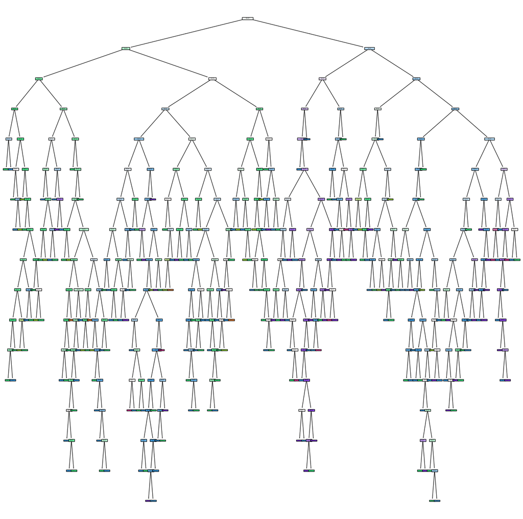

```python
from sklearn import tree
plt.figure(figsize=(20, 20))
tree.plot_tree(model, filled=True)
plt.savefig('decistion_tree.png')
```

**Top 20 sample data points from the dataframe**

```python
sampleData = dataframe.head(20)
sampleData
```

|  | fixed acidity | volatile acidity | citric acid | residual sugar | chlorides | free sulfur dioxide | total sulfur dioxide | density | pH | sulphates | alcohol | quality |
| --- | --- | --- | --- | --- | --- | --- | --- | --- | --- | --- | --- | --- |
| 0 | 7.4 | 0.700 | 0.00 | 1.9 | 0.076 | 11.0 | 34.0 | 0.9978 | 3.51 | 0.56 | 9.4 | 5 |
| 1 | 7.8 | 0.880 | 0.00 | 2.6 | 0.098 | 25.0 | 67.0 | 0.9968 | 3.20 | 0.68 | 9.8 | 5 |
| 2 | 7.8 | 0.760 | 0.04 | 2.3 | 0.092 | 15.0 | 54.0 | 0.9970 | 3.26 | 0.65 | 9.8 | 5 |
| 3 | 11.2 | 0.280 | 0.56 | 1.9 | 0.075 | 17.0 | 60.0 | 0.9980 | 3.16 | 0.58 | 9.8 | 6 |
| 4 | 7.4 | 0.700 | 0.00 | 1.9 | 0.076 | 11.0 | 34.0 | 0.9978 | 3.51 | 0.56 | 9.4 | 5 |
| 5 | 7.4 | 0.660 | 0.00 | 1.8 | 0.075 | 13.0 | 40.0 | 0.9978 | 3.51 | 0.56 | 9.4 | 5 |
| 6 | 7.9 | 0.600 | 0.06 | 1.6 | 0.069 | 15.0 | 59.0 | 0.9964 | 3.30 | 0.46 | 9.4 | 5 |
| 7 | 7.3 | 0.650 | 0.00 | 1.2 | 0.065 | 15.0 | 21.0 | 0.9946 | 3.39 | 0.47 | 10.0 | 7 |
| 8 | 7.8 | 0.580 | 0.02 | 2.0 | 0.073 | 9.0 | 18.0 | 0.9968 | 3.36 | 0.57 | 9.5 | 7 |
| 9 | 6.7 | 0.580 | 0.08 | 1.8 | 0.097 | 15.0 | 65.0 | 0.9959 | 3.28 | 0.54 | 9.2 | 5 |
| 10 | 5.6 | 0.615 | 0.00 | 1.6 | 0.089 | 16.0 | 59.0 | 0.9943 | 3.58 | 0.52 | 9.9 | 5 |
| 11 | 7.8 | 0.610 | 0.29 | 1.6 | 0.114 | 9.0 | 29.0 | 0.9974 | 3.26 | 1.56 | 9.1 | 5 |
| 12 | 8.5 | 0.280 | 0.56 | 1.8 | 0.092 | 35.0 | 103.0 | 0.9969 | 3.30 | 0.75 | 10.5 | 7 |
| 13 | 7.9 | 0.320 | 0.51 | 1.8 | 0.341 | 17.0 | 56.0 | 0.9969 | 3.04 | 1.08 | 9.2 | 6 |
| 14 | 7.6 | 0.390 | 0.31 | 2.3 | 0.082 | 23.0 | 71.0 | 0.9982 | 3.52 | 0.65 | 9.7 | 5 |
| 15 | 7.9 | 0.430 | 0.21 | 1.6 | 0.106 | 10.0 | 37.0 | 0.9966 | 3.17 | 0.91 | 9.5 | 5 |
| 16 | 8.5 | 0.490 | 0.11 | 2.3 | 0.084 | 9.0 | 67.0 | 0.9968 | 3.17 | 0.53 | 9.4 | 5 |
| 17 | 6.9 | 0.400 | 0.14 | 2.4 | 0.085 | 21.0 | 40.0 | 0.9968 | 3.43 | 0.63 | 9.7 | 6 |
| 18 | 6.3 | 0.390 | 0.16 | 1.4 | 0.080 | 11.0 | 23.0 | 0.9955 | 3.34 | 0.56 | 9.3 | 5 |
| 19 | 7.6 | 0.410 | 0.24 | 1.8 | 0.080 | 4.0 | 11.0 | 0.9962 | 3.28 | 0.59 | 9.5 | 5 |

```python
sampleData.describe()
```

|  | fixed acidity | volatile acidity | citric acid | residual sugar | chlorides | free sulfur dioxide | total sulfur dioxide | density | pH | sulphates | alcohol | quality |
| --- | --- | --- | --- | --- | --- | --- | --- | --- | --- | --- | --- | --- |
| count | 20.00000 | 20.000000 | 20.000000 | 20.00000 | 20.000000 | 20.000000 | 20.000000 | 20.000000 | 20.000000 | 20.000000 | 20.000000 | 20.000000 |
| mean | 7.66500 | 0.536250 | 0.164500 | 1.88000 | 0.097450 | 15.050000 | 47.400000 | 0.996725 | 3.328500 | 0.670500 | 9.575000 | 5.450000 |
| std | 1.07912 | 0.168342 | 0.191572 | 0.35333 | 0.058655 | 6.939399 | 22.558462 | 0.001048 | 0.146549 | 0.255744 | 0.330669 | 0.759155 |
| min | 5.60000 | 0.280000 | 0.000000 | 1.20000 | 0.065000 | 4.000000 | 11.000000 | 0.994300 | 3.040000 | 0.460000 | 9.100000 | 5.000000 |
| 25% | 7.37500 | 0.397500 | 0.000000 | 1.60000 | 0.075750 | 10.750000 | 32.750000 | 0.996350 | 3.245000 | 0.555000 | 9.400000 | 5.000000 |
| 50% | 7.70000 | 0.580000 | 0.095000 | 1.80000 | 0.083000 | 15.000000 | 47.000000 | 0.996800 | 3.300000 | 0.575000 | 9.500000 | 5.000000 |
| 75% | 7.90000 | 0.652500 | 0.252500 | 2.07500 | 0.093250 | 17.000000 | 61.250000 | 0.997500 | 3.450000 | 0.657500 | 9.800000 | 6.000000 |
| max | 11.20000 | 0.880000 | 0.560000 | 2.60000 | 0.341000 | 35.000000 | 103.000000 | 0.998200 | 3.580000 | 1.560000 | 10.500000 | 7.000000 |

```python
X_sample = sampleData.drop(columns='quality', axis=1)
y_sample = sampleData['quality']
```

```python
sampleModel = DecisionTreeClassifier()
sampleModel.fit(X_sample, y_sample)
```

```
DecisionTreeClassifier()
```

```python
sampleData.columns
```

```
Index(['fixed acidity', 'volatile acidity', 'citric acid', 'residual sugar',
       'chlorides', 'free sulfur dioxide', 'total sulfur dioxide', 'density',
       'pH', 'sulphates', 'alcohol', 'quality'],
      dtype='object')
```

```python
X_sample.columns
```

```
Index(['fixed acidity', 'volatile acidity', 'citric acid', 'residual sugar',
       'chlorides', 'free sulfur dioxide', 'total sulfur dioxide', 'density',
       'pH', 'sulphates', 'alcohol'],
      dtype='object')
```

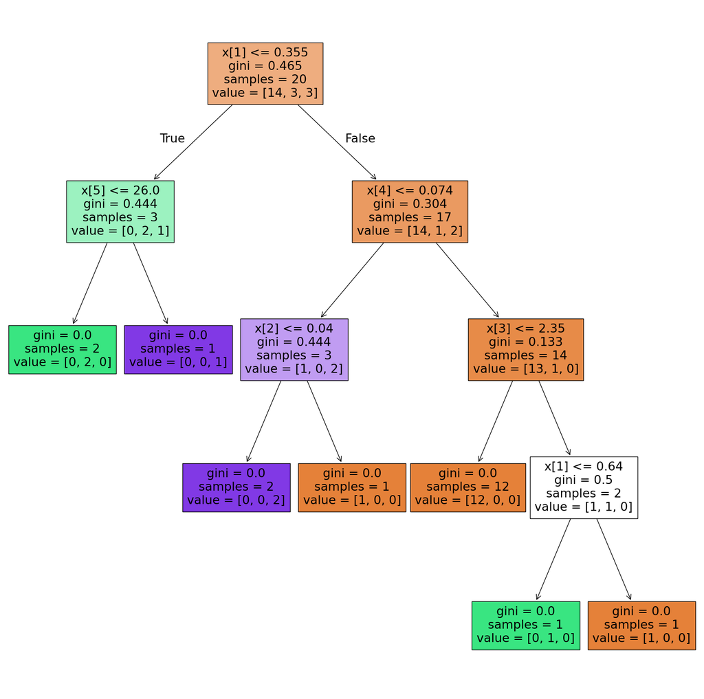

```python
from sklearn import tree
plt.figure(figsize=(20, 20))
tree.plot_tree(sampleModel, filled=True)
plt.savefig("Sample_Decistion_Tree.png")
```

**To understand how the decision tree in your image works, let’s break down the key components:**

### 1. **Feature Splitting: `x[1] <= 0.355`**

This represents the decision rule at the root of the decision tree. The tree splits based on this feature value (i.e., the feature at index `1`, denoted as `x[1]`).

- **Interpretation**: The tree checks whether the value of `x[1]` is less than or equal to `0.355`. If `True`, it moves to the left branch; if `False`, it moves to the right branch.

The process of selecting which feature and value to split on is determined by an algorithm (like CART) that tries to maximize information gain or minimize impurity (Gini index or entropy).

### 2. **Gini Index**

The **Gini Index** is a measure of impurity or disorder used in decision trees to determine the quality of a split. It tells us how pure or impure the nodes are.

- **Gini Index Formula**:

  ```
  Gini = 1 - ∑(p_i)^2
  ```

  where `p_i` is the probability of each class `i` in the node.
- **Gini Calculation**:
  - A node with a Gini index of `0` represents perfect purity, meaning all elements in that node belong to one class.
  - A Gini index closer to `1` indicates a higher impurity or a more diverse set of classes in that node.

### 3. **Samples**

- The number of **samples** represents the number of data points that reach a particular node.
  - At the root, we have `20 samples`, meaning the decision tree was trained on 20 data points.
  - As we move down the tree, the samples split across nodes depending on how the data satisfies the feature conditions.

For example:

- The root node has 20 samples.
- After the split, the left node (corresponding to `x[1] <= 0.355`) has `3 samples`, and the right node has `17 samples`.

### 4. **Value**

The **value** at each node represents the distribution of classes (target variable) at that point in the tree. The format of the value is usually:

```
value = [class_1_count, class_2_count, ..., class_n_count]
```

In your case, it looks like this tree is dealing with a classification problem involving 3 classes (or labels).

For example:

- The root node has `value = [14, 3, 3]`, meaning there are `14 samples` of class 1, `3 samples` of class 2, and `3 samples` of class 3 at the root.

As we move down the tree, the value becomes more concentrated towards a single class due to the splits, which helps the model classify the data.

### Putting It All Together:

- **Root Node** (`x[1] <= 0.355`):
  - **Gini**: `0.465` → Impurity measure at the root, indicating a mix of classes.
  - **Samples**: `20` → Total number of training samples at the root.
  - **Value**: `[14, 3, 3]` → Distribution of classes at the root node (14 of class 1, 3 of class 2, 3 of class 3).
- **Left Child Node** (result of the split `x[1] <= 0.355`):
  - **Gini**: `0.444` → Impurity measure at this node.
  - **Samples**: `3` → Three data points end up in this node.
  - **Value**: `[0, 2, 1]` → Two of class 2 and one of class 3.

Each split tries to reduce the Gini index, improving the tree’s ability to make accurate predictions by grouping similar data points together. The decision rules are chosen to maximize the difference in the Gini index between parent and child nodes.

### Why Feature `x[1] <= 0.355` is Chosen

The feature `x[1]` with the threshold `0.355` is selected because, at the root, it results in the best split according to the decision tree algorithm. This selection is based on maximizing the **information gain** or minimizing the **impurity** (Gini index, in this case). The algorithm evaluates different features and thresholds and picks the one that best separates the data points according to the target classes.

```python
set(sampleData.quality)
```

```
{5, 6, 7}
```

```python
from sklearn.metrics import classification_report
print(classification_report(y_pred, y_test))
```

```
              precision    recall  f1-score   support

           3       0.00      0.00      0.00         3
           4       0.00      0.00      0.00         2
           5       0.68      0.63      0.65       130
           6       0.57      0.55      0.56       117
           7       0.54      0.61      0.57        33
           8       0.00      0.00      0.00         1

    accuracy                           0.58       286
   macro avg       0.30      0.30      0.30       286
weighted avg       0.60      0.58      0.59       286
```